# updated_stroop

Welcome to the Stroop-Effect

The Dependent variable is the time taken to name the ink color. And the the independent variable is, the two different conditions. For example, whether the color and word is congruent or incongruent is independent with other conditions.

Now analysing the hypothesis : Null Hypothesis(H0) H0 : (myu sub c) X = (myu sub ic)Y, Y - X = 0, Alternative Hypothesis(H1) H1 : X < Y,

where X is average for the congruent variable and Y is average for incongruent variable.

We will perform dependent t-test for paired samples, because as the sample is not changing only the reading time is changing with the two conditions, congruent and incongruent.

We will perform a two tailed t-test for hypothesis testing for alpha level 0.05. The null hypothesis is H0 which means there will no difference in the reading times for the congruent and incongruent conditions. For alternative hypothesis H1 we can assume that there will be difference in positive direction, that is the average time taken for incongruent condition will be more than the congruent one.

A z-score and a t-score are both used in hypothesis testing. The reason for using T-score is that we have a sample size below 30, and an unknown population standard deviation. If the sample size is more than 30 and standard deviation is known then we can use a z-score.

The only difference between a z-test and a t-test is that for a z-test you have the exact standard error (calculated from the population standard deviation, σ) whereas for a t-test you have an estimate of the standard error (calculated from the sample standard deviation, s).

```python
import pandas as pd
import numpy as np
import matplotlib.pyplot as plt
%pylab inline
import seaborn as sns
```

```python
df = pd.read_csv('str.csv')
print len(df)
```

```
24
```

```python
df_congruent = df['Congruent']
print len(df_congruent)
```

```
24
```

```python
df_incongruent = df['Incongruent']
print len(df_incongruent)
```

```
24
```

```python
X = df_congruent.mean()
print X
```

```
14.051125
```

```python
Y = df_incongruent.mean()
print Y
```

```
22.0159166667
```

degree of freedom (df) = n - 1 = 24-1 = 23

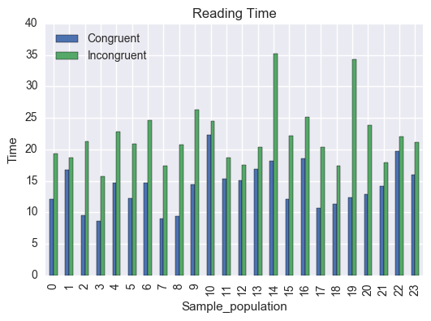

```python
my_plot = df.plot.bar(title="Reading Time")
my_plot.set_xlabel("Sample_population")
my_plot.set_ylabel("Time")
```

```python
 D = Y - X
print D
```

```
7.96479166667
```

The D here is the difference between the incongruent and congruent means, which is our point estimate.

After calculating the standard deviation for the differences we get the value 4.86482691

```python
S = 4.864
```

The standard deviation here is the S for calculating the t-statistic which can be calculated by the formula: t-statistic = (D)/(S/(sqrt(n))), and we get the t-statistic = 8.020706944

The t-critical for alpha level 0.05 is +2.069 and -2.069

The two-tailed P value for t-statistic = 8.020 and DF = 23, is less than 0.0001 By conventional criteria, this difference is considered to be extremely statistically significant.

Therefore we will reject the null hypothesis because the t-statistic value falls way far beyond the t-critical value. And our alternate hypothesis is true. So we can conclude that the time taken for congruent effect is less than the time taken for incongruent effect.

Cohen's d = D - S

```python
d = D - S
print d
```

```
3.10079166667
```

```python
MI = D*(S/sqrt(24))
print MI
```

```
7.90792179898
```

For calculating CI (Confidence Interval) :

```python
CIL = D - MI
print CIL
```

```
0.0568698676865
```

Here CIL is confidence interval for lower bound.

```python
CIU = D + MI
print CIU
```

```
15.8727134656
```

And CIU is confidence interval for upper bound

So based on our confidence interval, we can conclude that on average people takes 0.056 to 15.87 seconds more for incongruent effect than the congruent effect.